# The roller mechanic

In the last three lessons, we’ll create the roller mechanic. It’s a gameplay element made of a touch button, a path, and an end point.

## What we’ll create

When the player touches the starting point, a disk starts following the path. The player has to follow along with their finger until the end.

Instead of testing the player’s timing, the roller also tests their ability to follow a path over some time.

To convey the path’s direction, we’ll not only use the numbers on buttons; we’ll animate the path’s drawing in the direction the player should follow.

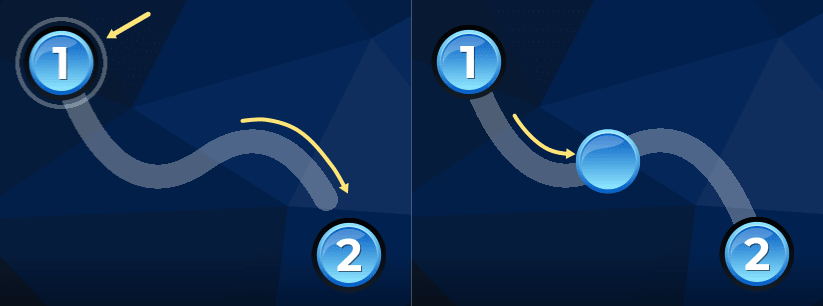

As I mentioned, the player should then follow the roller with their cursor or finger.

The longer they keep the cursor in the roller’s bounds, the more points they gain. To keep scoring consistent, we’ll have the best possible outcome be ten points.

So we have to implement the following features:

1. We need to define a path with its shape, length, and duration.
2. We need to check whether the player is following the path and keep track of the score.
3. We also need to animate the path growing to guide the player.

Let’s take a look at how we can separate these small problems into a coherent scene.

We’ll build a scene with the following structure. I outlined key nodes in yellow.

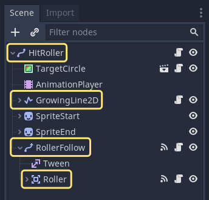

Here,

1. The root node, *HitRoller*, is a

[figure not shown]

   `Path2D` node. It allows us to draw the path in the editor.
2. *GrowingLine2D* is a

[figure not shown]

   `Line2D`, which we’ll use to draw the roller’s path and animate drawing.

[figure not shown]

   `Line2D` can draw both lines and curves and apply a gradient or size curve to them.
3. You can use a

[figure not shown]

   `PathFollow2D` node as a child of a

[figure not shown]

   `Path2D` to follow along the curve. Here, *RollerFollow* is a

[figure not shown]

   `PathFollow2D`. We’ll use it to move an area along the path.
4. Finally, the *Roller* node is an

[figure not shown]

   `Area2D` we use to track whether the cursor or finger follows the path.

With this in mind, let’s get started!

## Creating the HitRoller scene

Create a new scene with a

[figure not shown]

`Path2D` named *HitRoller* as the root and save the scene in the `RhythmGame/Hits/` directory.

We have a lot to do, but the good news is we can cheat a bit and reuse nodes we’ve already created and set up!

Right-click the root node and select *Merge From Scene*.

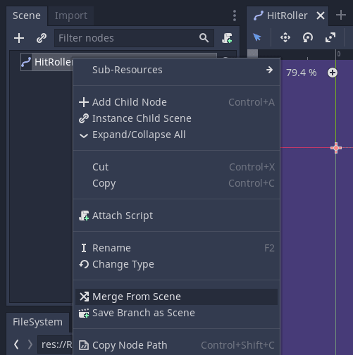

Open the `HitBeat.tscn` file and select its *Sprite*, *LabelCustom*, and *AnimationPlayer* before clicking *OK*.

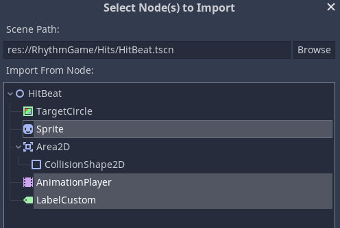

This copies the node to the scene. If you select the *AnimationPlayer*, you’ll see that we’ve copied over animations too.

[figure not shown]

*From Godot 3.3, you can copy and paste nodes across scenes directly from the scene tree.*

Our *HitRoller* needs two sprites: one at the start of the path and one at the end.

Make the *LabelCustom* a child of the *Sprite* and duplicate the two. I renamed the sprites to *SpriteStart* and *SpriteEnd*, respectively.

We move the labels as children as we’ll move *SpriteEnd* to the end of the path. Your scene should now look like this.

[figure not shown]

I renamed the *CustomLabel* nodes to *Label* too.

We can now attach a script to *HitRoller* and dive into the code. Predictably, we’re going to reuse some of the `HitBeat.gd` script too!

Except for this time, the root node type is

[figure not shown]

`Path2D`.

```
extends Path2D

var order_number := 0 setget set_order_number

# Whole-beats before the roller starts moving.
var _beat_delay := 4.0

onready var _sprite_start := $SpriteStart
onready var _label_start := $SpriteStart/Label
onready var _sprite_end := $SpriteEnd
onready var _label_end := $SpriteEnd/Label

onready var _animation_player := $AnimationPlayer


# When updating the number, we update the scene's labels to emphasize the path's
# direction. Unlike in `HitBeat.gd`, we have two nodes to update this time.
func set_order_number(number: int) -> void:
    order_number = number
    _label_start.text = str(number)
    _label_end.text = str(number + 1)
```

When adding an instance of `HitRoller` to the tree, we play its “show” animation.

```
func _ready() -> void:
    _animation_player.play("show")


func setup(data: Dictionary) -> void:
    # We get the curve's points and place the sprites on the first and last
    # points.
    var curve_points := curve.get_baked_points()
    _sprite_start.position = curve_points[0]
    _sprite_end.position = curve_points[curve_points.size() - 1]

    # We update the labels, position the node, and assign the sprites a color.
    self.order_number = data.order_number
    global_position = data.global_position

    _sprite_start.frame = data.color
    _sprite_end.frame = data.color


# We'll call this when the roller reached the end of the path.
func destroy() -> void:
    _animation_player.play("destroy")
```

To test our scene, we’re going to simulate it being instanced by populating a dictionary with information that’d normally be passed to it via the `Beatspawner`.

```
func _ready() -> void:
    #...
    var test_data := {global_position = global_position, order_number = 1, color = 0}

    setup(test_data)
```

Before running the scene, we must draw a path, as our script will try to access the curve’s points.

Select the root node, and click the *Add Point* icon in the toolbar. It’s the one with a green plus sign. Also, you need to be in *Select Mode* (`Q`) for the tool to work.

Then, you can click anywhere in the viewport to add points.

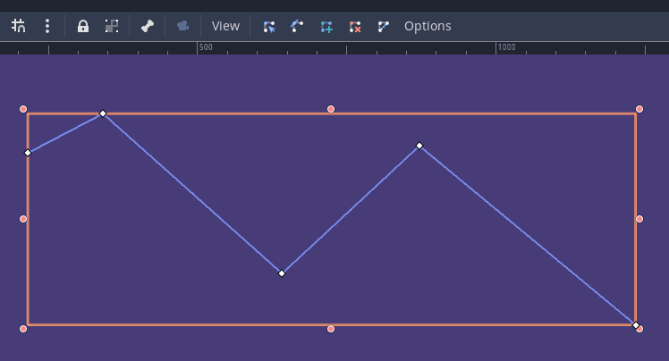

Run the scene by pressing `F6`.

So far, so good! Each sprite is placed correctly.

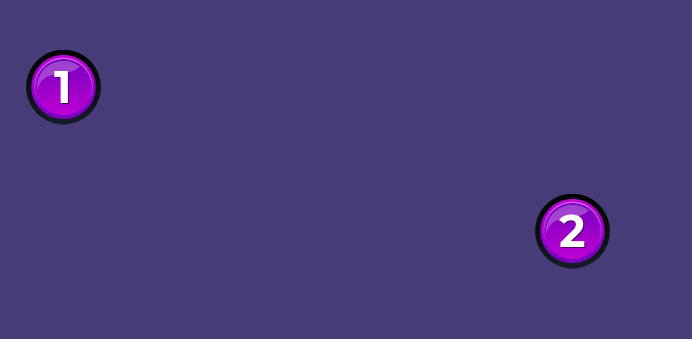

As you can see, the

[figure not shown]

`Path2D` curve isn’t rendered while the game runs, which is why we’ll create our next component: a growing line that will draw the curve.

## Creating the growing line

Add a

[figure not shown]

`Line2D` node as a child of *HitRoller* named *GrowingLine2D* and attach a script to it. Save the script alongside the `HitRoller.tscn` file.

Back to the scene, as children of *GrowingLine2D*, add a

[figure not shown]

`Timer` called *GrowthTimer* and a

[figure not shown]

`Tween` node.

[figure not shown]

The

[figure not shown]

`Line2D` node draws lines between

[figure not shown]

`Vector2` points. As luck would have it, the

[figure not shown]

`Path2D` curve is also made up of

[figure not shown]

`Vector2` points.

We can get the curve’s points and pass them to the

[figure not shown]

`Line2D` to draw it. We’ll use the timer to update the line and add points one by one, giving us that line drawing progressively.

Also, we’ll use the

[figure not shown]

`Tween` node to increase the line’s width over time.

We could use an

[figure not shown]

`AnimationPlayer` as well, but tweens are more flexible if you want to alter values such as duration, width, and so on through code.

In this case, being able to alter properties easily is desirable because we could save this *GrowingLine2D* as its own scene and reuse it elsewhere.

Before we move on to the script, we’ll set the *Default Color* of *GrowingLine2D* to be the same as the target circle for consistency. The hexadecimal value of this is `4affffff`. You can paste it into the color picker.

We also set all three *Capping* properties to *Round*.

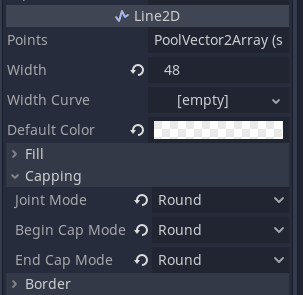

Rounded capping rounds out the curve on sharp turns and at either end of the curve.

On the left, you can see a line with the default settings. And on the right with the round caps and joint.

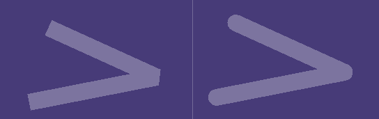

Connect the `timeout` signal to the `GrowingLine2D` script. Doing so will open up the script editor, so let’s get coding!

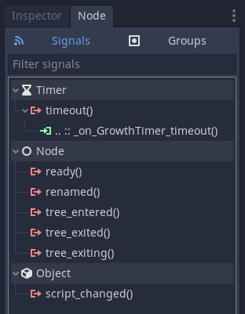

We’ll start, as always, by defining some properties.

```
extends Line2D

# The GrowthTimer's `wait_time`. Every time it times out, we add a point to the line.
export var timer_duration := 0.01
# The line's final width in pixels.
export var target_width := 48.0
# The line width animation's duration in seconds.
export var expand_duration := 1.0

# We'll store the curve's points here.
var _path_points := []

onready var _growth_timer := $GrowthTimer
onready var _tween := $Tween
```

The setup function takes a vector2 array as a parameter and stores it. We clear the line’s points to ensure we have a blank canvas to work with.

```
func setup(curve_points: PoolVector2Array) -> void:
    _path_points = curve_points

    clear_points()
```

Next, we define a `start()` function. When we call it, we start the timer and begin tweening the width.

```
func start() -> void:
    _growth_timer.start(timer_duration)

    _tween.interpolate_property(self, "width", 0, target_width, expand_duration, Tween.TRANS_LINEAR)
    _tween.start()
```

Finally, the method the timer is connected to grabs the first point in the cached array and adds it to the points to draw.

If there are no points left, the curve is complete, so we stop the timer.

```
func _on_GrowthTimer_timeout() -> void:
    if not _path_points:
        _growth_timer.stop()
        return

    add_point(_path_points.pop_front())
```

Head over to `HitRoller.gd` to set up and start drawing the line.

```
# ...
onready var _growing_line := $GrowingLine2D


func setup(data: Dictionary) -> void:
    #...

    _growing_line.setup(curve_points)
    _growing_line.start()
```

Rerunning the scene, we can see the line grow and follow the path!

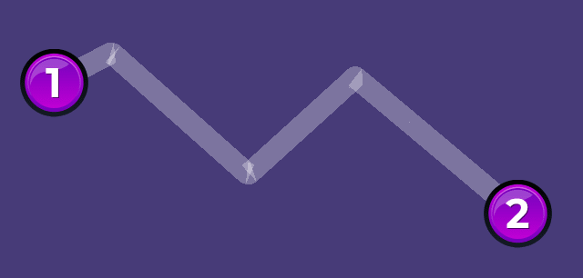

There’s overlap going on here, which is visible because we’re using a semi-transparent color and the corners are too harsh.

We can solve this using a shader or by smoothing out the corners. Here, we’ll do the latter.

Select the root node and use the *Select Control Points* tool.

It’s the second-from-left curve editing icon, with the shape of a curve.

With it, you can click and drag on any existing point to define the curve’s tangents and smooth out corners.

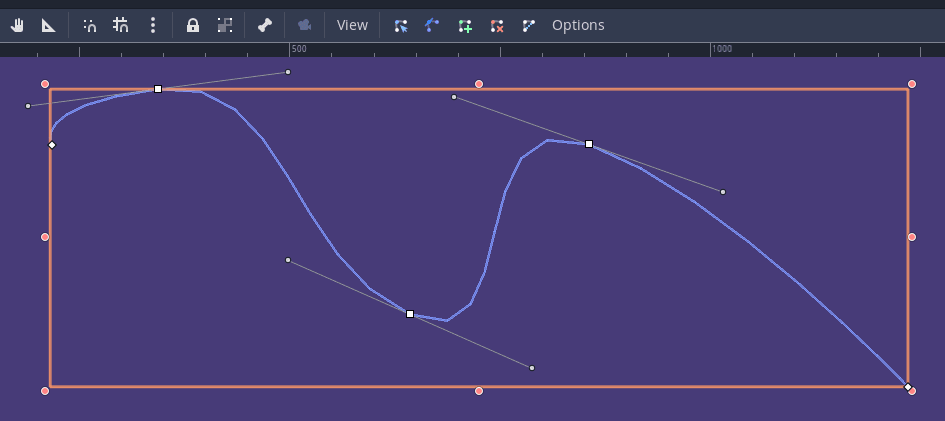

*Take note of how to manipulate curves in this way. We’ll be using the same technique to shape the curves for the roller placer scene.*

And there we go! Much more pleasing to the eye.

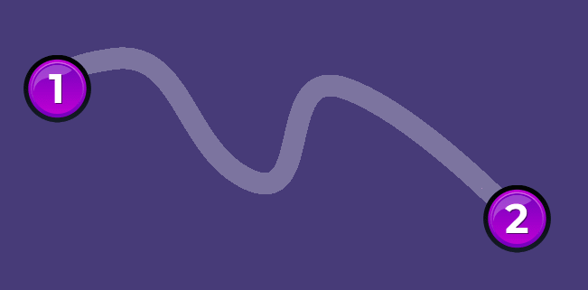

We’ll pause here to reflect on the fruits of our labor before managing the score and getting the roller moving in the next lesson.

See you there!

## Code reference

Here are the two scripts we created in this lesson.

`HitRoller.gd`

```
extends Path2D

var order_number := 0 setget set_order_number

var _beat_delay := 4.0

onready var _sprite_start := $SpriteStart
onready var _label_start := $SpriteStart/Label
onready var _sprite_end := $SpriteEnd
onready var _label_end := $SpriteEnd/Label
onready var _animation_player := $AnimationPlayer
onready var _growing_line := $GrowingLine2D


func _ready() -> void:
    _animation_player.play("show")
    var test_data := {global_position = global_position, order_number = 1, color = 0}

    setup(test_data)


func setup(data: Dictionary) -> void:
    var curve_points := curve.get_baked_points()
    _sprite_start.position = curve_points[0]
    _sprite_end.position = curve_points[curve_points.size() - 1]

    self.order_number = data.order_number
    global_position = data.global_position

    _sprite_start.frame = data.color
    _sprite_end.frame = data.color

    _growing_line.setup(curve_points)
    _growing_line.start()


func set_order_number(number: int) -> void:
    order_number = number
    _label_start.text = str(number)
    _label_end.text = str(number + 1)


func destroy() -> void:
    _animation_player.play("destroy")
```

`GrowingLine2D.gd`

```
extends Line2D

export var timer_duration := 0.01
export var target_width := 48.0
export var expand_duration := 1.0

var _path_points := []

onready var _growth_timer := $GrowthTimer
onready var _tween := $Tween


func setup(curve_points: PoolVector2Array) -> void:
    _path_points = curve_points

    clear_points()


func start() -> void:
    _growth_timer.start(timer_duration)

    _tween.interpolate_property(self, "width", 0, target_width, expand_duration, Tween.TRANS_LINEAR)
    _tween.start()


func _on_GrowthTimer_timeout() -> void:
    if not _path_points:
        _growth_timer.stop()
        return

    add_point(_path_points.pop_front())
```